# Grassland Vegetation - LTEM - Tunkwa Provincial Park

Published

2023-02-24

# 1 Summary of Grassland Vegetation LTEM protocol

## 1.1 Basic protocol

As taken from the protocol document: **I don’t have copy of protocol**

> “Permanent transects are established …. A 50cm X 50cm quadrat is sampled at regular intervals along the transect.

> The % foliar cover by species is recorded in each quadrat.”

The data collected under this protocol at each survey consists of the.

- Species. The species of vegetation in the plot.
- % foliar cover. What fraction of the plot is covered by this species.

## 1.2 Cautions about the protocol.

### 1.2.1 Don’t use 0 to indicate a missing value.

If a species was not seen on a plot during a visit, this is indicated by the lack of a record for that species code. Unfortunately, it is now impossible to know if the species were actually looked for and not seen, or the species could not be identified and so was not recorded. This issue could be problematic when looking at the impact of climate change where new species are introduced to the province. H ow it known that scientists from 20 years ago were able to recognize this plant? The current protocol involves identifying EVERY plant in the plot, so this may not be an issue, but it should be stressed in the protocol that EVERY plant needs to be identified so that missingness really implies a 0 cover value.

### 1.2.2 Replacing transects/plots

The protocol is silent on when and how to replace transect and/or plots. For example, is a plot is “damaged”, it should be simply dropped from further measuring for all subsequent years. However, if more than ½ of the plots are lost on a transect, then the entire transect should like be replaced. New transects should have a unique transect number (i.e. do not reuse transect labels). The old and new transect should be run in parallel for at least one season to calibrate the new transect with the existing transects.

### 1.2.3 Measuring % cover.

The protocol requires the actual % cover to be measured for each species, rather than simply classifying it into a category (e.g. between 20% and 30% cover). This is the preferred method. However, very rare species are assigned a categorical cover value (.5, .2 or .1 %). Given the rarity of these species, this should be fine.

### 1.2.4 Species recorded at Genus or Family or higher level.

This may be a bit problematic when species richness is recorded, as then a species may be double counted. Some editing of the data may be required before analyzing mean (plot) species richness. Presumably, the similarity matrix (Z) will indicate a high functional similarity between these Genus and Family levels and the distinct species so that the effective number of species diversity measures will be unaffected.

## 1.3 Database structure

The relevant fields in the database are

- *Transect*. The transect measured.
- *Plot*. The plot within the transect.
- *Date*. The date the data was collected. The Year is extracted from this date.
- *Species*. What species were seen
- *Percent Cover*. The percent cover of each species in the plot.

# 2 Reading and checking the data

The database was read for all records pertaining to the Tunkwa Provincial Park. The following surveys were found:

```
Surveys with the data
```

```
   SPI_PROJECT_ID SURVEY_ID          START_DATE        STUDY_AREA_NAME
14           5570     41257 2019-06-30 17:00:00 Tunkwa Provincial Park
```

```
Year
2019 2022 2023 2024 2025 2026
 295  295  295  295  295  295
```

The following data editing was performed

## 2.1 Variables names corrected for *R*

Variable names in *R* must start with a letter and contain letters or numbers or underscores. Blanks in variable names are not normally allowed, nor are special characters such as %. These are normally replaced by periods (“.”) in the variable name.

```
Original variable names in data frame
```

```
  [1] "PARENT_DESIGN_COMPONENT_ID"        "DESIGN_COMPONENT_ID"
  [3] "TAXONOMIC_UNIT_ID"                 "SURVEY_ID"
  [5] "SPI_PROJECT_ID"                    "STUDY_AREA_ID"
  [7] "STUDY_AREA_VISIT_ID"               "DESIGN_COMPONENT_VISIT_ID"
  [9] "VISIT_START_DATE"                  "VISIT_START_TIME"
 [11] "OBSERVATION_DATETIME"              "OBSERVATION_YEAR"
 [13] "OBSERVATION_MONTH"                 "OBSERVATION_DAY"
 [15] "VISIT_END_DATE"                    "VISIT_END_TIME"
 [17] "VISIT_TIME_SPAN"                   "VISIT_TIME_SPAN_UNIT_CODE"
 [19] "VISIT_TIME_SPAN_UNIT_NAME"         "VISIT_TIME_SPAN_UNIT_DEFN_URL"
 [21] "TRAP_EVENT_CODE"                   "TRAP_EVENT_NAME"
 [23] "TRAP_EVENT_DEFN_URL"               "TRAPS_SPRUNG"
 [25] "DISTANCE_COVERED_KM"               "NIGHTS_TRAPPED"
 [27] "SAMPLES"                           "VISIT_NOTE"
 [29] "NO_OBSERVATIONS_IND"               "TRIGGER_QUIET_PERIOD_SEC"
```

[output cut: 46 more lines]

```
Corrected variable names of data frame
```

```
  [1] "PARENT_DESIGN_COMPONENT_ID"        "DESIGN_COMPONENT_ID"
  [3] "TAXONOMIC_UNIT_ID"                 "SURVEY_ID"
  [5] "SPI_PROJECT_ID"                    "STUDY_AREA_ID"
  [7] "STUDY_AREA_VISIT_ID"               "DESIGN_COMPONENT_VISIT_ID"
  [9] "VISIT_START_DATE"                  "VISIT_START_TIME"
 [11] "OBSERVATION_DATETIME"              "OBSERVATION_YEAR"
 [13] "OBSERVATION_MONTH"                 "OBSERVATION_DAY"
 [15] "VISIT_END_DATE"                    "VISIT_END_TIME"
 [17] "VISIT_TIME_SPAN"                   "VISIT_TIME_SPAN_UNIT_CODE"
 [19] "VISIT_TIME_SPAN_UNIT_NAME"         "VISIT_TIME_SPAN_UNIT_DEFN_URL"
 [21] "TRAP_EVENT_CODE"                   "TRAP_EVENT_NAME"
 [23] "TRAP_EVENT_DEFN_URL"               "TRAPS_SPRUNG"
 [25] "DISTANCE_COVERED_KM"               "NIGHTS_TRAPPED"
 [27] "SAMPLES"                           "VISIT_NOTE"
 [29] "NO_OBSERVATIONS_IND"               "TRIGGER_QUIET_PERIOD_SEC"
```

[output cut: 46 more lines]

# 3 Number of years of data

The number of records by year is:

```
The number of records by year are
```

```
                        Year
STUDY_AREA_NAME          2019 2022 2023 2024 2025 2026
  Tunkwa Provincial Park  295  295  295  295  295  295
```

## 3.1 Checking Study Area Name

The Study Area Name should be recorded consistently across years, otherwise it may indicate that different sites are being studies. The study area name is converted to Title Case.

The list of Study Area Names by year in the data is:

```
                        Year
STUDY_AREA_NAME          2019 2022 2023 2024 2025 2026
  Tunkwa Provincial Park  295  295  295  295  295  295
```

You should also check the *PLOT* and *TRANSECT* labels for typos, e.g., inconsistencies across years in the transect or plot informatin. This is difficult to automate and needs a human touch.

```
        PLOT
TRANSECT T1P1 T1P10 T1P11 T1P12 T1P13 T1P14 T1P15 T1P16 T1P17 T1P18 T1P19 T1P2
      T1   90    48    54    54    66    72    36    54    66    60    30   84
        PLOT
TRANSECT T1P20 T1P21 T1P22 T1P23 T1P24 T1P25 T1P26 T1P27 T1P28 T1P29 T1P3 T1P30
      T1    54    42    48    48    36    48    42    42    54    54   66    48
        PLOT
TRANSECT T1P4 T1P5 T1P6 T1P7 T1P8 T1P9
      T1   84   60   78  102   72   78
```

```
      TRANSECT
Year    T1
  2019 295
  2022 295
  2023 295
  2024 295
  2025 295
  2026 295
```

```
      PLOT
Year   T1P1 T1P10 T1P11 T1P12 T1P13 T1P14 T1P15 T1P16 T1P17 T1P18 T1P19 T1P2
  2019   15     8     9     9    11    12     6     9    11    10     5   14
  2022   15     8     9     9    11    12     6     9    11    10     5   14
  2023   15     8     9     9    11    12     6     9    11    10     5   14
  2024   15     8     9     9    11    12     6     9    11    10     5   14
  2025   15     8     9     9    11    12     6     9    11    10     5   14
  2026   15     8     9     9    11    12     6     9    11    10     5   14
      PLOT
Year   T1P20 T1P21 T1P22 T1P23 T1P24 T1P25 T1P26 T1P27 T1P28 T1P29 T1P3 T1P30
  2019     9     7     8     8     6     8     7     7     9     9   11     8
  2022     9     7     8     8     6     8     7     7     9     9   11     8
  2023     9     7     8     8     6     8     7     7     9     9   11     8
  2024     9     7     8     8     6     8     7     7     9     9   11     8
  2025     9     7     8     8     6     8     7     7     9     9   11     8
  2026     9     7     8     8     6     8     7     7     9     9   11     8
      PLOT
Year   T1P4 T1P5 T1P6 T1P7 T1P8 T1P9
  2019   14   10   13   17   12   13
  2022   14   10   13   17   12   13
  2023   14   10   13   17   12   13
  2024   14   10   13   17   12   13
  2025   14   10   13   17   12   13
  2026   14   10   13   17   12   13
```

```
        PLOT
TRANSECT T1...T1P1 T1...T1P10 T1...T1P11 T1...T1P12 T1...T1P13 T1...T1P14
      T1        90         48         54         54         66         72
        PLOT
TRANSECT T1...T1P15 T1...T1P16 T1...T1P17 T1...T1P18 T1...T1P19 T1...T1P2
      T1         36         54         66         60         30        84
        PLOT
TRANSECT T1...T1P20 T1...T1P21 T1...T1P22 T1...T1P23 T1...T1P24 T1...T1P25
      T1         54         42         48         48         36         48
        PLOT
TRANSECT T1...T1P26 T1...T1P27 T1...T1P28 T1...T1P29 T1...T1P3 T1...T1P30
      T1         42         42         54         54        66         48
        PLOT
TRANSECT T1...T1P4 T1...T1P5 T1...T1P6 T1...T1P7 T1...T1P8 T1...T1P9
      T1        84        60        78       102        72        78
```

## 3.2 Checking species code

The species codes should be the “same* across all years, i.e., consistent case, etc.

```
SPECIES_CODE
   ACHIMIL   ACHNOCC1    ACHNRIC    ANTEMIC      ASTER ASTERACEAE   ASTRMIS2
       164         61        120        109         69         26         46
 BRYOPHYTA    CAREPET      CAREX    CERAARV   COMAUMB2    DANTINT   FABACEAE
       107         14         13        154         61         30          2
   FESTCAM      FUNGI   JUNCBAL3    KOELMAC       NULL    PENSPRO    POA PRA
        87        108         83         16        198         31        134
   POACEAE    POTEGRA    PSEUSPI    RHINMIN    TARAOFF    TRAGDUB  TRIFOLIUM
         7          6         29         51         26         15          3
```

```
            Year
SPECIES_CODE 2019 2022 2023 2024 2025 2026
  ACHIMIL      25   29   25   30   34   21
  ACHNOCC1     11    9   11    8   14    8
  ACHNRIC      20   20   19   12   25   24
  ANTEMIC      21   18   20   18   14   18
  ASTER        12   11   14   14   12    6
  ASTERACEAE    4    4    5    5    3    5
  ASTRMIS2      8    5    7   10   10    6
  BRYOPHYTA    18   20   16   18   18   17
  CAREPET       2    1    3    3    4    1
  CAREX         2    1    1    3    3    3
  CERAARV      25   27   27   23   22   30
  COMAUMB2     11   12   10    8   13    7
  DANTINT       5    6    6    4    6    3
  FABACEAE      1    0    1    0    0    0
  FESTCAM      16   16   14   16    9   16
  FUNGI        17   20   19   17   13   22
  JUNCBAL3     13   13    8   21   12   16
  KOELMAC       3    3    1    3    4    2
  NULL         30   33   39   29   27   40
  PENSPRO       4    9    3    6    3    6
  POA PRA      22   25   21   26   19   21
  POACEAE       1    0    1    2    1    2
  POTEGRA       1    0    0    1    3    1
  PSEUSPI       6    2    5    2    8    6
  RHINMIN       8    8   13    8    9    5
  TARAOFF       5    2    5    6    3    5
  TRAGDUB       3    1    1    2    4    4
  TRIFOLIUM     1    0    0    0    2    0
```

Note that the value of *NULL* indicates no vegetation was recorded on this plot and is not a species. These values will be deleted

```
[1] 1770  121
```

```
[1] 1572  121
```

```
SPECIES_CODE
   ACHIMIL   ACHNOCC1    ACHNRIC    ANTEMIC      ASTER ASTERACEAE   ASTRMIS2
       164         61        120        109         69         26         46
 BRYOPHYTA    CAREPET      CAREX    CERAARV   COMAUMB2    DANTINT   FABACEAE
       107         14         13        154         61         30          2
   FESTCAM      FUNGI   JUNCBAL3    KOELMAC    PENSPRO    POA PRA    POACEAE
        87        108         83         16         31        134          7
   POTEGRA    PSEUSPI    RHINMIN    TARAOFF    TRAGDUB  TRIFOLIUM
         6         29         51         26         15          3
```

## 3.3 Check the Percent Cover values

The percent cover values should be numeric and not missing.

```
PERCENT_COVER
0.1 0.5   1 1.5   2 2.5   3   4   5   6   7   8 8.5  10  12  14  15  20  25  30
 82 180 382  37 187  22 169  59 133  16  22   9  11  93  14   7  79  23  22  12
 45  60  71
  4   6   3
```

# 4 Single Site Analysis

Date for the Tunkwa Provincial Park are available from 2019 to 2026.

This design has multiple transects that are repeated measured over time with multiple plots measured on each transect that are also repeated measured over time. Please refer to the *Fitting Trends with Complex Study Designs* document in the CommonFile directory for information on fitting trends with complex study designs.

All analyses were done using the R (R Core Team, 2022) analysis system. The *R* code is general enough that if more than one transect is present, it will automatically choose the more complex linear mixed models as seen in the other protocols. All plots are also saved as separate *png files for inclusion into other reports.

## 4.1 Total Cover.

The data is first summarized to the plot level by summing the % cover, excluding non-plant coverage (e.g. rocks). Then the average total % cover for each transect is computed by averaging the total % cover over the plots within each transect. This makes an implicit assumption that all transects will have the same set of plots measured over time. If some plots have to be discarded (e.g. due to damage), the analysis will only be approximate, but unless the number of discarded plots is very large (e.g. more than a 1/3), the approximation should be adequate. This makes the unit of the analysis, the transect within each year.

A summary plot of the total % cover on each plot is shown in Figure Figure 1. .

```
         STUDY_AREA_NAME Year TRANSECT    cover
1 Tunkwa Provincial Park 2019       T1 43.17333
2 Tunkwa Provincial Park 2022       T1 48.20333
3 Tunkwa Provincial Park 2023       T1 41.20667
4 Tunkwa Provincial Park 2024       T1 37.86667
5 Tunkwa Provincial Park 2025       T1 36.90000
6 Tunkwa Provincial Park 2026       T1 35.72333
```

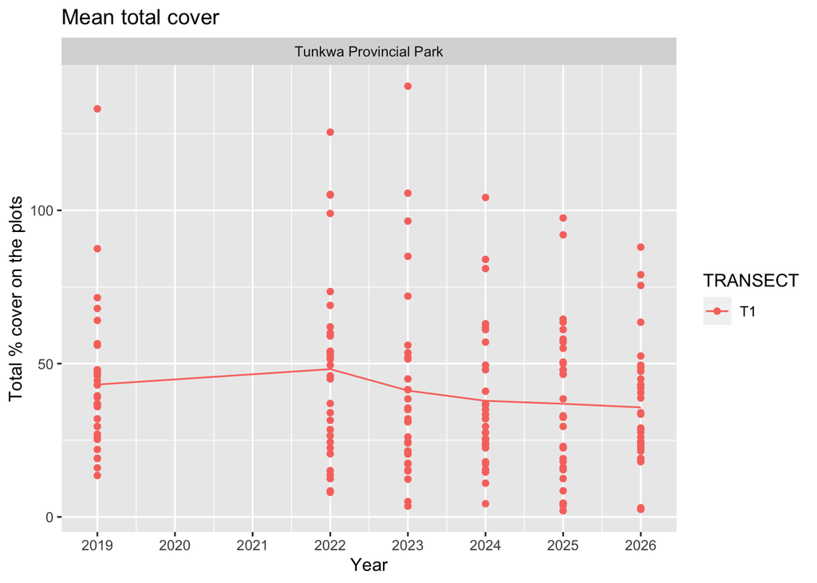

Figure 1: Summary plot of the total % cover. Each dot represents a plot on the transect.

A linear mixed model regression can be used to look for changes over time using the model
$$\mathit{TotalCover} = \mathit{Year} + \mathit{TransectF(R)}+ \mathit{YearF(R)}$$
where

- $\mathit{TotalCover}$ the mean (over plots) total % cover for a transect in a year;
- $\mathit{TransectF}$ represents the (random) transect effect;
- $\mathit{YearF}$ represents the year-specific effects (process error); and
- $\mathit{Year}$ represents the calendar year trend over time.

Plants on a plot are a mixture of annuals, biennials and perennials so the year-specific effects may vary by species and so in the context of total cover, the year-specific effects are an average over all species.

These models are fit using the *lmer()* functions in *R* and results summarized in Figure 2.

```
            STUDY_AREA_NAME     slope  slope.se    p.value
Year Tunkwa Provincial Park -1.380721 0.6425278 0.09810386
```

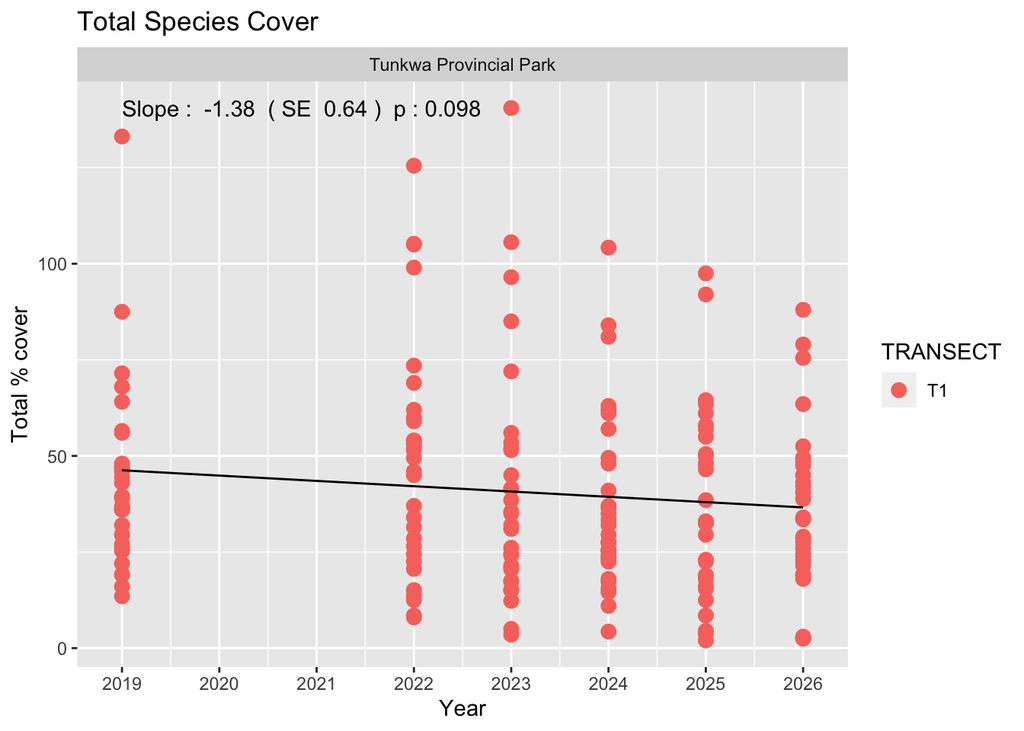

Figure 2: Summary plot of the trend in total % cover.

Figure 2 shows a summary plot, along with estimates of the slope, its standard error, and the p-value of the hypothesis of no trend. With 6 years of data, the estimated slope is -1.381 (SE 0.643) percent cover/year (p = 0.098).

[output not shown]

[output not shown]

It will also be possible to covariates such as soil condition in a transect to try and explain some of the variation over time using a multiple regression. With only 6 years of data available, this not sensible.

Whenever an analysis of a trend over time is conducted, the analysis should test and adjust for autocorrelation. Autocorrelation usually isn’t a problem (and likely cannot be detected) unless you have 10+ years of data. The test for autocorrelation commonly used is the Durbin-Watson test and we find p = 0.710 for the test of no autocorrelation.

This analysis was conducted at the total count level (over all species) and also for individual species – but the data are likely to very sparse and not useful for individual species. One potential problem is that in some cases, species information is only recorded at the Genus or higher level. In these case, this data will have to discarded when the analysis is done at the species level, but then you are making an implicit assumption that recording at the Genus level happens at random and is unrelated to the response.

The analysis of the % cover for an individual species would follow similar steps as shown above. However, for species with smaller % cover, it is advisable to transform the observed % cover to an empirical logit(% cover)
$$logit(\% cover) = log \left( {\frac{\%cover}{100\%-\%cover}} \right)$$
to avoid the regression line from going below 0% or above 100%, following the recommendation of Warton and Hui (2011). You will also have to impute 0 values if the species is not listed found in a plot in a year.

The R code is easy to modify.

## 4.2 Species richness.

A similar analysis can be applied to the average species richness at the plot level as in the previous section. The data is first summarized to the plot level by counting the number of plant species, excluding non-plant coverage (e.g. rocks). Some case is needed when plants are only identified to the Genus or Family level – these may have to be removed to avoid double counting. For example, in the test dataset, there were cases where the id was unknown and the plant was labeled “unknown #1”. This was not acceptable to the SPI database, so an identification was given to the level it was known which was sometimes as vague as *Poaceae* (family) or *Dicotyledoneae* (class). It is assumed that a plant was a different species than all the others that were known when it is labelled as “unknown2”

Then the average species richness (at the plot level) for each transect is computed by averaging the species richness over the plots within each transect. This makes an implicit assumption that all transects will have the same set of plots measured over time so that the transect mean richness has roughly the same precision in all transects. If some plots have to be discarded (e.g. due to damage), the analysis will only be approximate, but unless the number of discarded plots is very large (e.g. more than a 1/3), the approximation should be adequate. This makes the unit of the analysis, the transect within each year.

A summary plot of the species richness on each plot is shown in Figure 3. .

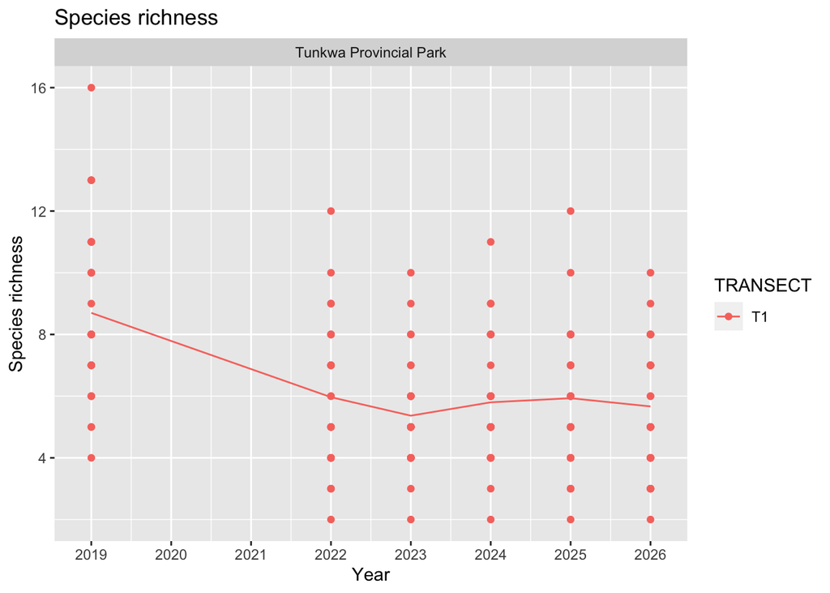

Figure 3: Summary plot of the data for mean species richness at the plot level. Each dot represents a plot on the transects.

A linear mixed model regression can be used to look for changes over time using the model
$$\mathit{Richness} = \mathit{Year} + \mathit{TransectF(R)}+ \mathit{YearF(R)}$$
where

- $\mathit{Richness}$ the mean species richness for a transect in a year;
- $\mathit{TransectF}$ represents the (random) transect effect;
- $\mathit{YearF}$ represents the year-specific effects (process error); and
- $\mathit{Year}$ represents the calendar year trend over time.

Plants on a plot are a mixture of annuals, biennials and perennials so the year-specific effects may vary by species and so in the context of total richness, the year-specific effects are an average over all species.

The summarized data on species richness is:

```
         STUDY_AREA_NAME Year TRANSECT richness
1 Tunkwa Provincial Park 2019       T1 8.700000
2 Tunkwa Provincial Park 2022       T1 5.966667
3 Tunkwa Provincial Park 2023       T1 5.366667
4 Tunkwa Provincial Park 2024       T1 5.800000
5 Tunkwa Provincial Park 2025       T1 5.933333
6 Tunkwa Provincial Park 2026       T1 5.666667
```

These models are fit using the *lmer()* functions in *R* and results summarized in Figure 4.

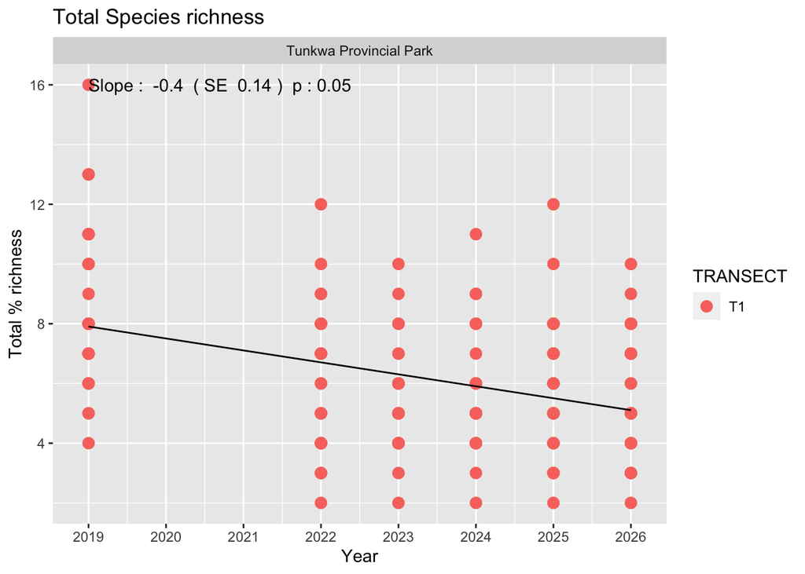

Figure 4: Summary plot of the trend in species richness.

Figure 4 shows a summary plot, along with estimates of the slope, its standard error, and the p-value of the hypothesis of no trend. With 6 years of data, the estimated slope is -0.4 (SE 0.144) specues richness/year (p = 0.050).

[output not shown]

[output not shown]

It will also be possible to covariates such as soil condition in a transect to try and explain some of the variation over time using a multiple regression. With only 6 years of data available, this not sensible.

Whenever an analysis of a trend over time is conducted, the analysis should test and adjust for autocorrelation. Autocorrelation usually isn’t a problem (and likely cannot be detected) unless you have 10+ years of data. The test for autocorrelation commonly used is the Durbin-Watson test and we find p = 0.356 for the test of no autocorrelation.

A potential weakness of this approach is that richness if computed for each plot separately. So two plots each with completely different set of species would have the same plot richness, but the richness for the entire transect would be much higher. The next section indicates ways to deal with this problem.

## 4.3 Diversity

Species richness is one measure of diversity and there are many more such as Simpson’s or Shannon’s measure of diversity. A similar analysis as for species richness can be done on these other measures of diversity, but are no longer recommended because these measures are often insensitive to big changes in diversity and because they do not account for functional similarity among species. For example, the diversity of six dramatically different species of plants is considered to be no more diverse than six related species.

Leinster and Cobbold (2012) showed how different diversity measures all belong to a continuum (called a diversity profile) and how species similarity can be used to augment the standard diversity measures. The diversity profile also has a number of advantages over the traditional measures of diversity as noted by Chao and Jost (2013) and Jost (2013).

The key difficulty with traditional measures of diversity is that there is non-linear relationship between the diversity measure and biological implications. For this reason, it is often useful to think in terms of “effective number of species” (Jost, 2006; Jost 2013). Briefly, the effective number of species is the number of equally abundant species that give rise to a particular diversity index value.

Jost (2013) provides an example of the problems with traditional diversity measures:

> “… suppose you are comparing the diversity of aquatic microorganisms before and after an oil spill. You wouldn’t want to measure that diversity by species richness because even a massive toxic event is sure to leave a few vagrant individuals of each pre-spill species, and species richness doesn’t distinguish between one individual of Species X or a million; the pre- and post-spill species counts might not be very different, even if the pre- and post-spill species frequencies are very different. So if you are a good traditional biologist you might use the popular Gini-Simpson diversity index, which is $1-\sum_i{p_i^2}$ where $p_i$ is a measure of relative abundance for species i. Suppose that the pre-spill Gini-Simpson index is .99 and the post-spill index is .97. If you are a good traditional biologist you would figure out that this drop is statistically significant, but you would conclude that the magnitude of the drop is small. You might even say (very wrongly) that the diversity has dropped by 2%, which sounds like a small drop, nothing to worry about.

> The error which virtually all biologists make is that the Gini-Simpson index is not itself a diversity, and is highly nonlinear. The pre-spill community with a Gini-Simpson index of 0.99 has the same diversity as a community of 100 equally-common species. The post-spill community with a Gini-Simpson index of 0.97 has the same diversity as a community of 33 equally-common species. The difference between the pre-and post-spill diversities is in fact enormous. The drop in diversity is 66%, not 2%! This is not just a matter of different definitions of diversity, as some people would like to say. Rather, it is a matter of the indices being nonlinear with respect to our intuitive concept of diversity.”

Leinster and Cobbold (2012) defined the diversity profile as series of “effective numbers” dependent on an index $q$ (which ranges from 0 to infinity) and a similarity matrix $\bf{Z}$ (whose $(i,j)$ entry measures the similarity of species $i$ and species $j$ from 0 (not similar) to 1 (completely similar)). The diversity profile is computed as:
$$^{q}D^Z(\bf{p})= \left( {\sum {p_i(\bf{Zp})^{q-1}_i}} \right) ^{1/(1-q)}$$
where the vector $\bf{p}$ is the relative abundance of the species present (i.e., excluding species with 0 abundance), and $\bf{Z}$ is the similarity matrix among the vector of species. As shown by Leinster and Cobbold (2012), many of the common diversity indices are special cases of the above. For example, if $q = 0$, the above equation reduces to species richness; if $q = 1$ and $\bf{Z}=\bf{I}$, then the above is related to the Shannon Index; and if $q=2$ and $\bf{Z}=\bf{I}$, then the above is related to the Simpson Index of diversity.

I’ve included a briefing note on the analysis of diversity in an environmental impact assessment case with this material as illustration of the method. For the rest of this section, the diversity measures will be computed assuming a diagonal $\bf{Z}$ matrix, i.e. every species is functionally distinct which is obviously incorrect.

Once the diversity profiles have been computed, the effective number of species for any value of $q$ can be extracted and analyzed in the same way as the analysis for the average species richness.

For example, here are the extracted diversity values for $q = 2$ which is related to the Simpson Index of diversity:

```
        STUDY_AREA_NAME Year TRANSECT q diversity
 Tunkwa Provincial Park 2019       T1 2       8.0
 Tunkwa Provincial Park 2022       T1 2       6.2
 Tunkwa Provincial Park 2023       T1 2       7.4
 Tunkwa Provincial Park 2024       T1 2       8.2
 Tunkwa Provincial Park 2025       T1 2       8.4
 Tunkwa Provincial Park 2026       T1 2       8.8
```

A summary plot of the effective number of species over time: is shown in Figure 5.

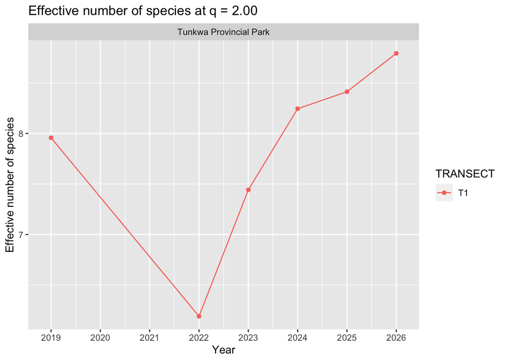

Figure 5: Summary plot of the effective number of species for q of 2.

A linear mixed model regression can be used to look for changes over time using the model
$$\mathit{EffectiveSpecies} = \mathit{Year} + \mathit{TransectF(R)}+ \mathit{YearF(R)}$$
where

- $\mathit{EffectiveSpecies}$ the mean species diversity for a transect in a year;
- $\mathit{TransectF}$ represents the (random) transect effect;
- $\mathit{YearF}$ represents the year-specific effects (process error); and
- $\mathit{Year}$ represents the calendar year trend over time.

Plants on a plot are a mixture of annuals, biennials and perennials so the year-specific effects may vary by species and so in the context of total diversity, the year-specific effects are an average over all species.

These models are fit using the *lmer()* functions in *R* and results summarized in Figure 6.

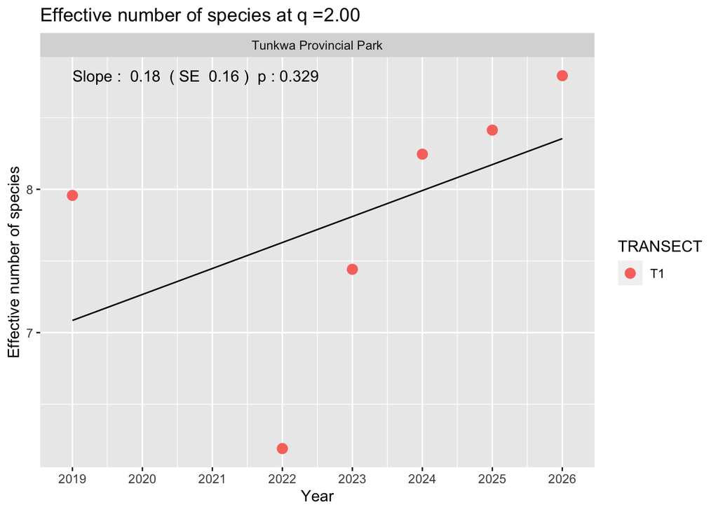

Figure 6: Summary plot of the trend in species diversity (effective number of species).

Figure 6 shows a summary plot, along with estimates of the slope, its standard error, and the p-value of the hypothesis of no trend. With 6 years of data, the estimated slope is 0.181 (SE 0.163) specues diversity/year (p = 0.329).

[output not shown]

[output not shown]

It will also be possible to covariates such as soil condition in a transect to try and explain some of the variation over time using a multiple regression. With only 6 years of data available, this not sensible.

Whenever an analysis of a trend over time is conducted, the analysis should test and adjust for autocorrelation. Autocorrelation usually isn’t a problem (and likely cannot be detected) unless you have 10+ years of data. The test for autocorrelation commonly used is the Durbin-Watson test and we find p = 0.932 for the test of no autocorrelation.

## 4.4 Species turn over and nestedness

Cover and diversity measures may not capture species turn over. For example, cover and diversity could remain the same, while a entirely new set of species replaces existing species.

Collins et al. (2017) decomposed compositional changes over time in components due to nestedness or turnover. Nestedness measures dissimilarity in species composition relative to the first year of the study and is due to plots in later years containing fewer species than the plot in the first year of measurement. Turnover measures dissimilarity in species composition relative to the first year of the study due to plot in later years containing new species not found in the first year of measurement.

These measures are computed for each plot on each transect. First, for each plot for each year, the percentage of cover is translated into a presence/absence score (presence if the % cover >0). Let

- $a$ = number of species appears on the plot in the first year and in year $k$;
- $b$ = number of species occurring in the first year but not in year $k$; and
- $c$ = the number of species occurring in year $k$ but not in year $1$.

Then three measures of dissimilarity are computed

$$\beta_{sor} = \frac{b+c}{2a+b+c}$$
$$\beta_{sim} = \frac{min(b,c)}{a+min(b,c)}$$
$$\beta_{nest} = \beta_{sor} - \beta_{sim}$$

$\beta_{sor}$ accounts for the total difference in species composition between the two years; $\beta_{sim}$ accounts only for the lower component. For example, if the same set of species were present in both years, then $b=c=0$ and all three indices are zero. If some species simply vanish (but no new species arrive) then $b$ = the number of species that disappear, $a$ = number of species that persist; and $c$ = 0 and $\beta_{sim}=0$ while the two other components are non-zero. If some species are new in year $k$ but no species disappears, then $b=0$ and again $\beta_{sim}=0$. Only if there is turnover, i.e., some species disappear and other species take their place, do we get a non-zero value for $\beta_{sim}$.

The values of the three indices were found for each plot in year subsequent to the first year the transect was measured. A minimum of 4 years of data are required. The mean dissimilarity measure over all plots within a transect was computed to get a measure for each transect for each year as shown in Figure 7.

```
          STUDY_AREA_NAME TRANSECT Year betatype mean.dissim
1  Tunkwa Provincial Park       T1 2022 beta.sim   0.0000000
2  Tunkwa Provincial Park       T1 2022 beta.sne   0.1996746
3  Tunkwa Provincial Park       T1 2022 beta.sor   0.1996746
4  Tunkwa Provincial Park       T1 2023 beta.sim   0.0000000
5  Tunkwa Provincial Park       T1 2023 beta.sne   0.2348401
6  Tunkwa Provincial Park       T1 2023 beta.sor   0.2348401
7  Tunkwa Provincial Park       T1 2024 beta.sim   0.0000000
8  Tunkwa Provincial Park       T1 2024 beta.sne   0.2017709
9  Tunkwa Provincial Park       T1 2024 beta.sor   0.2017709
10 Tunkwa Provincial Park       T1 2025 beta.sim   0.0000000
11 Tunkwa Provincial Park       T1 2025 beta.sne   0.1985273
12 Tunkwa Provincial Park       T1 2025 beta.sor   0.1985273
13 Tunkwa Provincial Park       T1 2026 beta.sim   0.0000000
14 Tunkwa Provincial Park       T1 2026 beta.sne   0.2192801
15 Tunkwa Provincial Park       T1 2026 beta.sor   0.2192801
```

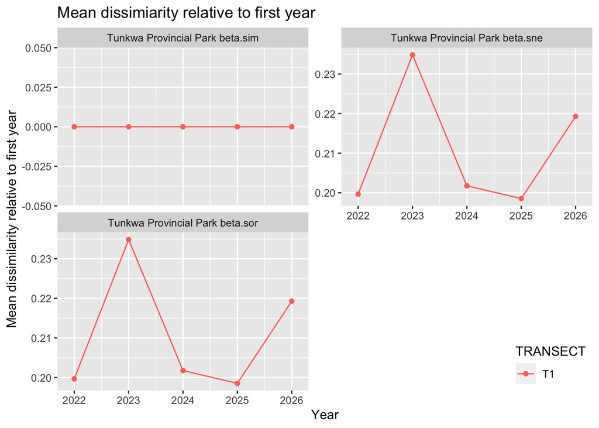

Figure 7: Three dissimilarity measures (relative to the first year of measurement) The beta.sor measures total change over time; beta.sim measures turn over (species dropping out and being replaced); beta.sne measures nestedness (species persisting over time). Note that beta.sim + beta.sne = beta.sor.

The values for each transect are then regressed over time. Notice that you need at least 4 years of measurements because each year is compared to the first year which leave 3 dissimilarity values which is the minimum needed for a regression analysis.

```
*** Starting analysis on beta diversity type  beta.sim
Model could not not be fit


*** Starting analysis on beta diversity type  beta.sne
Model could not not be fit


*** Starting analysis on beta diversity type  beta.sor
Model could not not be fit
```

[output not shown]

[output not shown]

[output not shown]

[output not shown]

[output not shown]

[output not shown]

[output not shown]

[output not shown]

[output not shown]

[output not shown]

[output not shown]

[output not shown]

[output not shown]

[output not shown]

[output not shown]

[output not shown]

# 5 Power analysis

A power/sample size analysis was conducted to determine the number of years of sampling needed to detect changes over time. The steps in the power/sample size analysis are:

- Compute a single number summarizing the response at this site in each year. The mean % total cover is computed at the transect level and must be averaged over transects.
- Analyze the log(mean response) using a simple linear regression. This will give an estimate of the combined year-specific and sampling variation around regression line (overall sd).
- Use the overall SD to estimate power and sample size requirements.

Here are the overall means for each year for each response:

```
         STUDY_AREA_NAME Year TRANSECT    cover
1 Tunkwa Provincial Park 2019       T1 43.17333
2 Tunkwa Provincial Park 2022       T1 48.20333
3 Tunkwa Provincial Park 2023       T1 41.20667
4 Tunkwa Provincial Park 2024       T1 37.86667
5 Tunkwa Provincial Park 2025       T1 36.90000
6 Tunkwa Provincial Park 2026       T1 35.72333
```

```
          STUDY_AREA_NAME Year Mean.response            Response
1  Tunkwa Provincial Park 2019     43.173333    Mean total cover
2  Tunkwa Provincial Park 2022     48.203333    Mean total cover
3  Tunkwa Provincial Park 2023     41.206667    Mean total cover
4  Tunkwa Provincial Park 2024     37.866667    Mean total cover
5  Tunkwa Provincial Park 2025     36.900000    Mean total cover
6  Tunkwa Provincial Park 2026     35.723333    Mean total cover
7  Tunkwa Provincial Park 2019      8.700000       Mean richness
8  Tunkwa Provincial Park 2022      5.966667       Mean richness
9  Tunkwa Provincial Park 2023      5.366667       Mean richness
10 Tunkwa Provincial Park 2024      5.800000       Mean richness
11 Tunkwa Provincial Park 2025      5.933333       Mean richness
12 Tunkwa Provincial Park 2026      5.666667       Mean richness
13 Tunkwa Provincial Park 2019      7.957535 Mean diversity: q=2
14 Tunkwa Provincial Park 2022      6.191034 Mean diversity: q=2
15 Tunkwa Provincial Park 2023      7.441763 Mean diversity: q=2
16 Tunkwa Provincial Park 2024      8.245166 Mean diversity: q=2
17 Tunkwa Provincial Park 2025      8.413216 Mean diversity: q=2
18 Tunkwa Provincial Park 2026      8.792864 Mean diversity: q=2
```

The above data needs to be checked if there are any suspicious values.

We use the *lm()* function to fit linear regression over time on the log(scale) and obtain the combined year-specific effect (process error) plus sampling variation standard deviation (Table 1).

Table 1: Estimated residual (process + sampling) standard deviation

| Response | Process + sampling SD |
| --- | --- |
| Mean diversity: q=2 | 0.1249 |
| Mean richness | 0.1159 |
| Mean total cover | 0.0828 |

This is then used to estimate the power to detect various proportional changes over time (Figure 8).

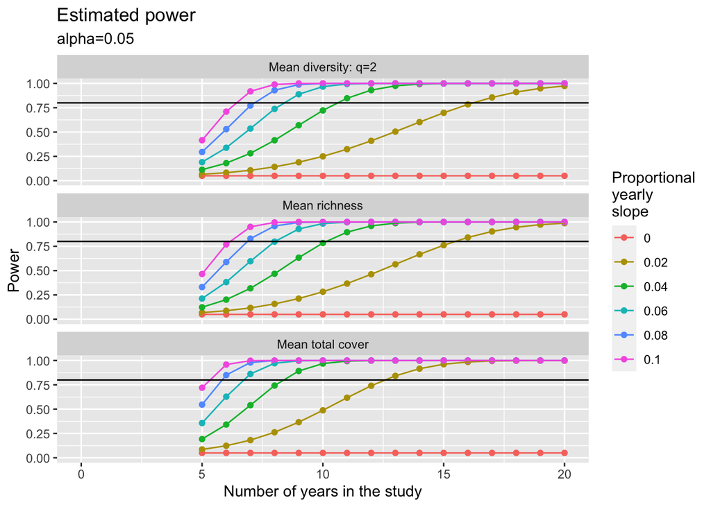

Figure 8: Estimated power to detect proportional changes over time

The proportional yearly slope indicates the effect size of interest. For example, a value of .02 would indicated a 2% change/year in the mean response.

In cases of high variability, the power is uniformly low to detect the yearly proportion change over time. In cases of low variability, power is uniformly very high to detect the yearly proportion change over time.

# 6 Summary

A key feature of this protocol is that the transect is the analysis unit and individual plots are pseudo-replicates within a transect (Hurlbert, 1984). It is not wise to treat the individual plots as analysis units because they may not be independent due to transect-specific factors (such as aspect) that affect all of the plots within the transect simultaneously. If plots are treated as the analysis unit, then typically, the residual variation is underestimated, reported standard errors of estimates are too small, and reported p-values are too small leading to too many false positive results.

There are several measures that can be monitored over time. Among the simplest are simple averages of total % cover or plot-level species richness.

Species richness is one of many measures of diversity. Recent work has places it and other measures on a continuum where the effective number of species (also called the Hill number) is a more sensible measure of diversity. This can account for both the relative abundance of species and also their functional similarity. The latter (the Z matrix above) needs to be developed to effectively use these newer methods for diversity.

Beta diversity and ordination methods are usually used when community structures are measured across a gradient (e.g. environmental gradient) and the relationship between the community structure and the environmental variables are of interest. This does not appears to be of of interest here and are not pursued. But changes in beta diversity over time can be partitioned into species persistence (nestedness) and species turnover (species being lost and replaced) using presence/absence data related to the percentage cover. At least 4 sample events will be needed for trend analysis because each sampling event is compared to the species present in the first year of sampling.

# 7 References

Chao, A. and Jost, L. (2013). Diversity Analysis. Chapman and Hall.

Collins, et. al. (2017). Fragmentation affects plant community composition over time. Ecography, 40, 119-140.

Jost, L. (2013). Effective number of species. Available at http://www.loujost.com/Statistics%20and%20Physics/Diversity%20and%20Similarity/EffectiveNumberOfSpecies.htm. Downloaded 2013-12-10.

Kuznetsova A, Brockhoff PB, Christensen RHB (2017). lmerTest Package: Tests in Linear Mixed Effects Models. Journal of Statistical Software, 82, 1-26. doi:10.18637/jss.v082.i13

Leinster, T. and Cobbold, C. A. (2012). Measuring diversity: the importance of species similarity. Ecology, 93, 477-489.

R Core Team (2022). R: A language and environment for statistical computing. R Foundation for Statistical Computing, Vienna, Austria. https://www.R-project.org/.

Warton, D.I. and Hui, F.K.C. (2010) The Arcsine Is Asinine: The Analysis of Proportions in Ecology. Ecology, 92, 3-10.